# Statistics & Application Course Project

Zahra Sadat Bahri

# Question 1

## Part A:

### i) An exponential distribution with $\lambda = 2$

Exponential distribution describes times between events happening at constant rate λ with expected value 1/λ

Here, imagine its the day of judgment and corpses are waking up, and on average, every half second one of them rises. Assume a corpse wakes up and let $t$ be the times passed until the next one’s resurrection. The area of the plot between $x$ and $x+dx$ is the probability of $t \in \{x , x+dx\}$.

PDF of $y = \lambda e ^{-\lambda x} \rightarrow Variance = \frac{1}{\lambda^2} = 0.25 , \mu = 0.5$

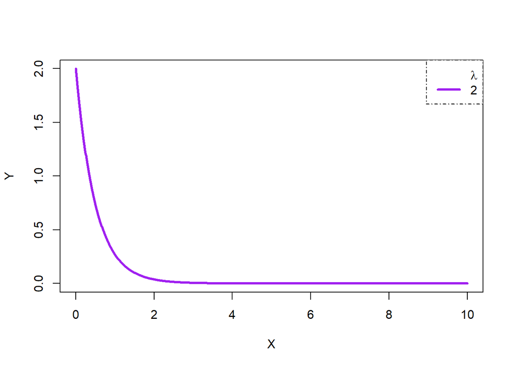

```r
# Grid of X-axis values
x <- seq(0, 10, 0.01)

# lambda = 2
plot(x, dexp(x, 2), type = "l",
     ylab = "Y",xlab = "X", lwd = 3, col = "purple")

# Adding a legend
legend("topright", c(expression(paste(, lambda)), "2"),
       lty = c(0, 1), col = c("purple"), box.lty = 4, lwd = 3)
```

### ii & iii) Doing n experiments with 50 samples

```r
#define function: takes n as input,
                  # for n times, gets 50 random uniform samples, calculates the mean, adds it to a vector
                  #draws the histogram

calc_mean <- function(n) {
  samp = 50 #in case someone wants to change it
  means_vec = c()

  for (i in 1:n) {
    x <- rexp(samp, 2)
    single_mean = mean(x)
    means_vec = c(means_vec, single_mean)
  }


  print(paste("The Sample Statistics After " , n , " Experiments: Mean = " , round(mean(means_vec),4) , " ,Variance = ", round(var(means_vec),4)))

  cltvar = round(1 / sqrt(4 * n), 4)

  print(paste("using CLT the normal distribution properties are: mean = 1 ,variance=", cltvar))



  # plot the histogram
  hist(means_vec,prob = T, main = paste('No. of Experiments = ', n), xlim = c(0, 1), xlab = 'X', ylab = 'Y', col="purple")

  # fit a normal curve to the histogram
  lines(density(means_vec), col="magenta", lwd=3) # add a density estimate with defaults
  lines(density(means_vec, adjust=2), lty="dashed", col="darkblue", lwd=3)


  #draw the CLT curve for distribution of mean:
  x_dt <- seq(0, 10, 0.01)
  y_dt <- dnorm(x_dt, 0.5, 1 /(2* sqrt(n)))

  # plotting the normal distribution
  lines(x_dt, y_dt, type = 'l', col = 'red', lwd = 2.5, xlab = 'X', ylab = 'Y', xlim = c(0,1))


# Adding a legend
legend("topright", c("fit normal", "real curve", "CLT" ),
       lty = c(2, 1,1), col = c("darkblue","magenta", "red"), box.lty = 4, lwd = 3)



}
```

Doing 10 experiments: n = 10

```r
calc_mean(10)
```

```
## [1] "The Sample Statistics After  10  Experiments: Mean =  0.4921  ,Variance =  0.0079"
## [1] "using CLT the normal distribution properties are: mean = 1 ,variance= 0.1581"
```

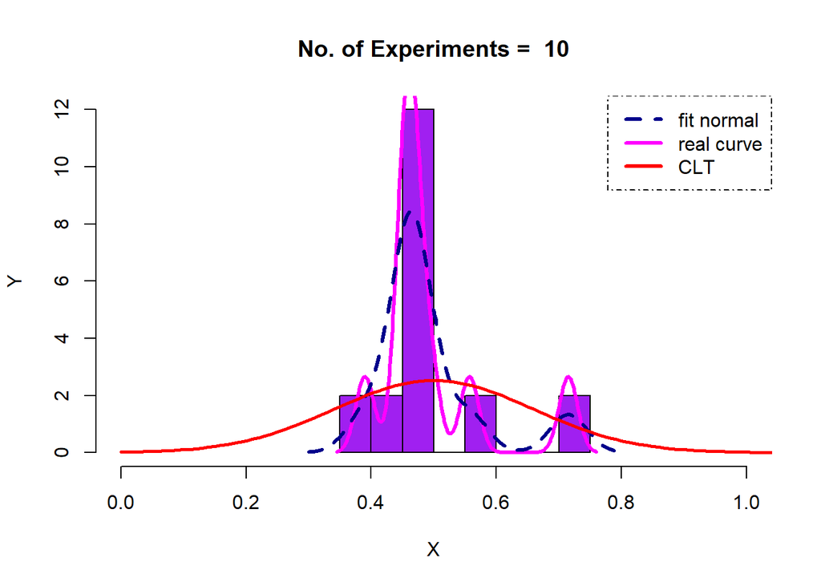

Doing 100 experiments: $ n = 100$

```r
calc_mean(100)
```

```
## [1] "The Sample Statistics After  100  Experiments: Mean =  0.4996  ,Variance =  0.0065"
## [1] "using CLT the normal distribution properties are: mean = 1 ,variance= 0.05"
```

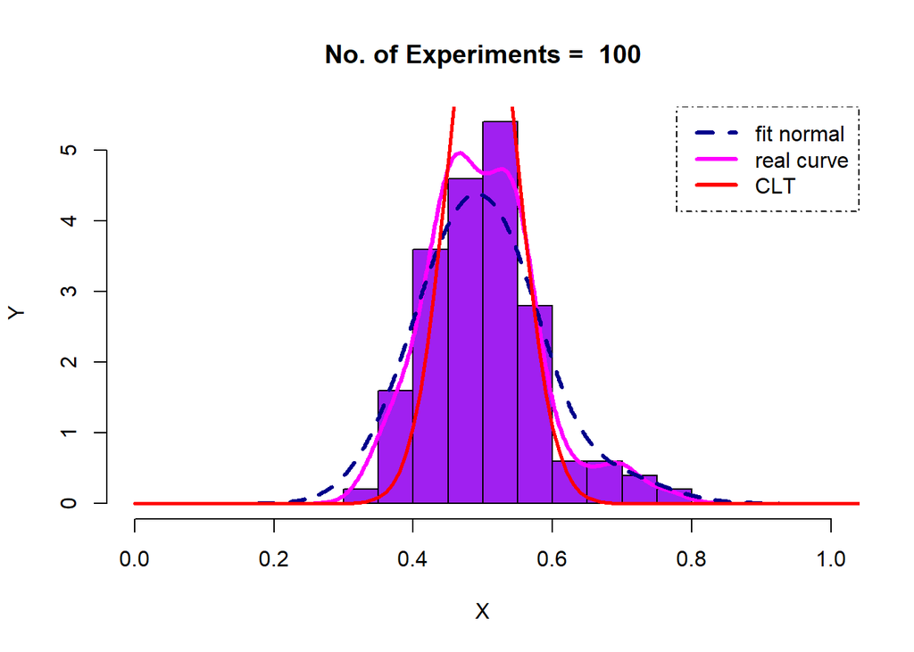

Doing 1000 experiments: $ n = 1000$

```r
calc_mean(1000)
```

```
## [1] "The Sample Statistics After  1000  Experiments: Mean =  0.4973  ,Variance =  0.0047"
## [1] "using CLT the normal distribution properties are: mean = 1 ,variance= 0.0158"
```

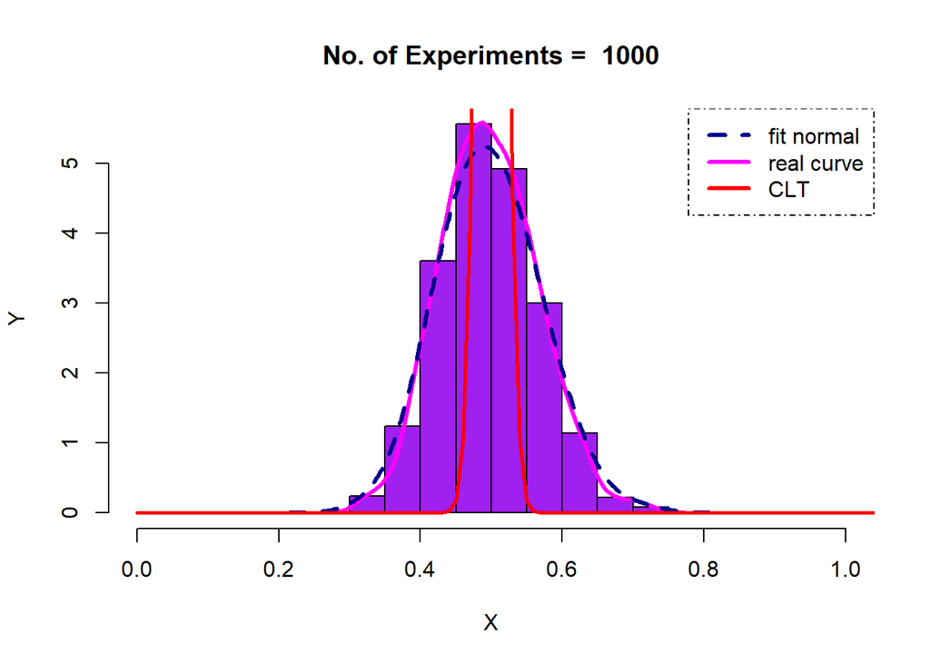

**Conclusion:** By increasing the number of experiments the variance of the curve decreases.

## Part B:

### i) days with min and max birth

#### The day with minimum number of births:

```r
head(filter(Births, `births` == min(births))['date'])
```

| date |
| --- |
| 1976-05-09 |

#### The day with maximum number of births:

```r
head(filter(Births, `births` == max(births))['date'])
```

| date |
| --- |
| 1988-09-20 |

### ii) average of each month

Not Sorted:

```r
mon_avg = summarize(group_by(Births, month), average = mean(births))
head(mon_avg,'all')
```

| month | average |
| --- | --- |
| 1 | 9288.976 |
| 2 | 9491.301 |
| 3 | 9464.742 |
| 4 | 9267.958 |
| 5 | 9331.000 |
| 6 | 9597.618 |
| 7 | 10032.734 |
| 8 | 10177.039 |
| 9 | 10343.287 |
| 10 | 9766.729 |
| 11 | 9492.122 |
| 12 | 9523.187 |

Sorted (Descending):

```r
#order = avg
sorted <- mon_avg[order(-mon_avg$average),]
head(sorted, 'all')
```

| month | average |
| --- | --- |
| 9 | 10343.287 |
| 8 | 10177.039 |
| 7 | 10032.734 |
| 10 | 9766.729 |
| 6 | 9597.618 |
| 12 | 9523.187 |
| 11 | 9492.122 |
| 2 | 9491.301 |
| 3 | 9464.742 |
| 5 | 9331.000 |
| 1 | 9288.976 |
| 4 | 9267.958 |

### iii) Average of each year

```r
#order = avg of each year
yavg = summarize(group_by(Births, year), average = mean(births))
head(yavg, 'all')
```

| year | average |
| --- | --- |
| 1969 | 9859.118 |
| 1970 | 10231.797 |
| 1971 | 9761.847 |
| 1972 | 8923.123 |
| 1973 | 8618.274 |
| 1974 | 8685.770 |
| 1975 | 8639.359 |
| 1976 | 8678.322 |
| 1977 | 9128.899 |
| 1978 | 9145.745 |
| 1979 | 9588.321 |
| 1980 | 9885.104 |
| 1981 | 9960.219 |
| 1982 | 10096.915 |
| 1983 | 9980.085 |
| 1984 | 10036.970 |
| 1985 | 10315.216 |
| 1986 | 10303.238 |
| 1987 | 10447.153 |
| 1988 | 10693.404 |

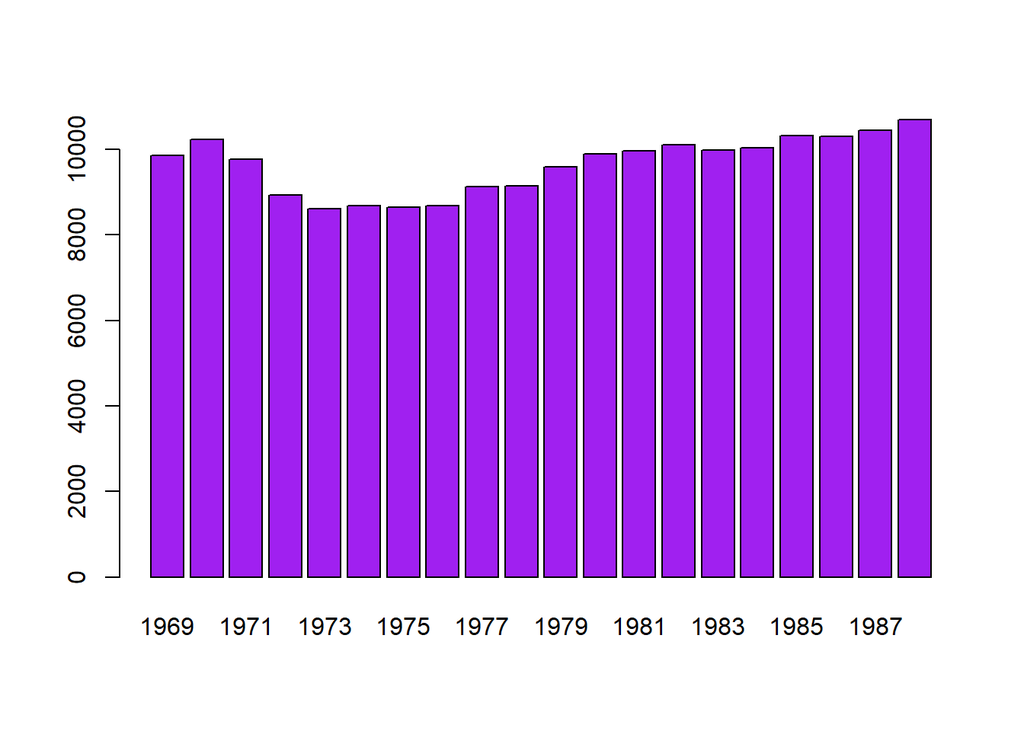

```r
#plotting
barplot(names = yavg$year, height = yavg$average,col="purple")
```

## Part C:

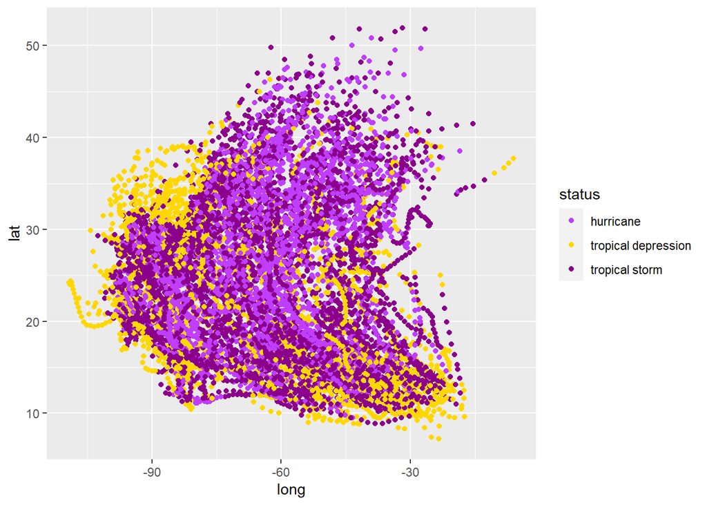

```r
#sort: most recent on top:
write.csv(storms[order(-storms$year,-storms$month,-storms$day,-storms$hour),], file = 'storm_reports.csv')


# plot
sp = ggplot(storms, aes(x = long, y = lat, colour = status)) + geom_point()
sp + scale_color_manual(values=c("darkorchid1", "gold", "darkmagenta"))
```

Here is the data shown on a real map:

```r
#set borders of the map (5 is the margin so dots won't end up on the border of the picture)

border <- c(
  left = min(storms$long)-5,
  bottom = min(storms$lat)-5,
  right = max(storms$long)+5,
  top = max(storms$lat)+5
)

#get map image

map <- get_stamenmap(
  bbox = border,
  zoom = 5
)
```

```
## 77 tiles needed, this may take a while (try a smaller zoom).
```

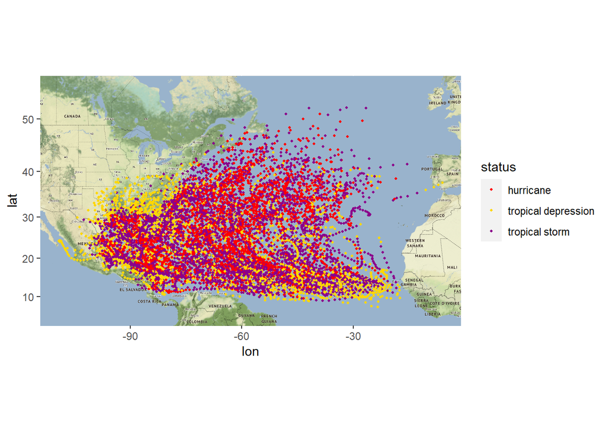

```r
ggmap(map)+
geom_point(
    data = storms,
    mapping = aes(x = long, y = lat, color = status)
    , size = 0.75
  ) + scale_color_manual(values=c("red", "gold", "darkmagenta"))
```

# Question 2

## Part A:

### i) Importing the data

```r
#loading data
df = read.delim("had.txt")

#set column names
colnames(df) = c('age', 'sex', 'pain', 'blood_pressure', 'cholesterol', 'boold_sugar', 'heart_attack')

features = df[,c('age', 'sex', 'pain', 'blood_pressure', 'cholesterol', 'boold_sugar')]
label = df[c('heart_attack')]
head(features,'all')
```

| age | sex | pain | blood_pressure | cholesterol | boold_sugar |
| --- | --- | --- | --- | --- | --- |
| 63 | 0 | 0 | 124 | 197 | 0 |
| 57 | 1 | 1 | 124 | 261 | 0 |
| 44 | 1 | 1 | 130 | 219 | 0 |
| 54 | 0 | 2 | 108 | 267 | 0 |
| 40 | 1 | 0 | 152 | 223 | 0 |
| 59 | 1 | 2 | 150 | 212 | 1 |
| 67 | 1 | 0 | 160 | 286 | 0 |
| 57 | 0 | 1 | 130 | 236 | 0 |
| 57 | 1 | 0 | 140 | 192 | 0 |
| 61 | 1 | 0 | 148 | 203 | 0 |
| 34 | 0 | 1 | 118 | 210 | 0 |
| 50 | 1 | 2 | 129 | 196 | 0 |
| 58 | 1 | 2 | 112 | 230 | 0 |
| 48 | 1 | 1 | 110 | 229 | 0 |
| 54 | 1 | 2 | 150 | 232 | 0 |
| 62 | 1 | 1 | 128 | 208 | 1 |
| 56 | 0 | 0 | 200 | 288 | 1 |
| 64 | 1 | 3 | 170 | 227 | 0 |
| 64 | 1 | 0 | 128 | 263 | 0 |
| 54 | 1 | 2 | 120 | 258 | 0 |
| 35 | 1 | 0 | 120 | 198 | 0 |
| 29 | 1 | 1 | 130 | 204 | 0 |
| 68 | 1 | 2 | 180 | 274 | 1 |
| 46 | 1 | 1 | 101 | 197 | 1 |
| 62 | 0 | 0 | 140 | 394 | 0 |
| 46 | 0 | 1 | 105 | 204 | 0 |
| 57 | 1 | 2 | 150 | 168 | 0 |
| 66 | 0 | 3 | 150 | 226 | 0 |
| 52 | 1 | 3 | 118 | 186 | 0 |
| 44 | 1 | 1 | 120 | 220 | 0 |

[output cut: 272 more lines]

### ii) Split into “test” and “train”

```r
set.seed(13)
#how many is is 80% of data?
n =  floor(.8 * nrow(df))
```

Getting n random rows by generating n random numbers

```r
random = sample.int(n = nrow(df), size =n, replace = F)

# split label
train_label = label[random, ]
test_label = label[-random, ]

#split feature:
train_feature = features[random, ]
test_feature  = features[-random, ]
```

saving data frames into txt files

```r
write.table(train_label,"train_label.txt",sep="\t",row.names=FALSE)

write.table(test_label,"test_label.txt",sep="\t",row.names=FALSE)

write.table(train_feature,"train_feature.txt",sep="\t",row.names=FALSE)

write.table(test_feature,"test_feature.txt",sep="\t",row.names=FALSE)
```

## Part B:

### i)

Extracting the 80% of data to fit a line to:

```r
reg <- lm(heart_attack ~ age + sex + pain+ blood_pressure+cholesterol+ boold_sugar, df[random, ])
```

```r
summary(reg)
```

```
##
## Call:
## lm(formula = heart_attack ~ age + sex + pain + blood_pressure +
##     cholesterol + boold_sugar, data = df[random, ])
##
## Residuals:
##      Min       1Q   Median       3Q      Max
## -2.05309 -0.65082 -0.01603  0.72724  1.74629
##
## Coefficients:
##                 Estimate Std. Error t value Pr(>|t|)
## (Intercept)     2.340062   0.541022   4.325 2.26e-05 ***
## age            -0.020916   0.006534  -3.201  0.00156 **
## sex            -0.583702   0.123510  -4.726 3.95e-06 ***
## pain            0.340025   0.053956   6.302 1.45e-09 ***
## blood_pressure -0.004950   0.003372  -1.468  0.14347
## cholesterol    -0.001448   0.001123  -1.290  0.19824
## boold_sugar    -0.128837   0.156518  -0.823  0.41126
## ---
## Signif. codes:  0 '***' 0.001 '**' 0.01 '*' 0.05 '.' 0.1 ' ' 1
##
## Residual standard error: 0.8585 on 234 degrees of freedom
## Multiple R-squared:  0.2766, Adjusted R-squared:  0.258
## F-statistic: 14.91 on 6 and 234 DF,  p-value: 1.983e-14
```

#### Coefficients, Standard deviation, t-value, Residuals, Residual standard error, Multiple R-squared, F-statistic and R-squared is given

As we can see, all the coefficients (including the intercept) are given **plus** each one’s standard deviation and t-value. (Recall that standard deviation can be used to estimate confidence intervals and t-value is useful for figuring out whether the related variable which the coefficient belongs to, has a meaningful regression with y axis variable.)

When the coefficients are calculated and the line is drawn, each point has a distance from it. If the regression is meaningful and the real realation between data is linear, then points are expected to be close to this line. Residual is defined as the difference between the observed value and the mean value that the model predicts for that observation. Residual values are especially useful in regression and ANOVA procedures because they indicate the extent to which a model accounts for the variation in the observed data.

$$r = x - x_0$$
where x is the measured variable and $x_0$ is the approximate variable.

Here we have minimum and maximum residual in addition to median, 1Q and 3Q. Note that for min and max residua, they don’t need to be necessarily close to 0 for regression to be good, since they can be literally the outliers.

R-squared ($R^2$) is a statistical measure that represents the proportion of the variance for a dependent variable that’s explained by an independent variable or variables in a regression model.

$$R^2 = 1- \frac{RSS}{TSS}$$
where $R^2$ = coefficient of determination, RSS = sum of squares of residuals, and TSS = total sum of squares,

### iii) What parameters are the most and the least related?

First of all **do NOT use the (absolute) value of the coefficients** since that largely depends on units and scaling of the data. If we try to analyze data using coefficients, Sex will be the most effective feature in causing a heart attack (largest absolute value of coefficient) and cholesterol will be the least efficient one (smallest absolute value of coefficient).

However, looking at t-values( ) we see that **pain** is the most related and effective parameter with highest t-value and blood sugar is the least. ( any t-value$\notin [-2, 2]$ is acceptable). The t-value measures the size of the difference relative to the variation in your sample data. Put another way, T is simply the calculated difference represented in units of standard error. The greater the magnitude of T, the greater the evidence against the null hypothesis.

## Part C:

### i) Estimation with limit = 0

```r
#using model on test data:
prdction <- predict.lm(reg, test_feature)
```

Now we set 1 for “having the heart attack” and -1 for the oppsite to make data comparable to label vector

```r
# < 0 => no heart attack
prdction[prdction < 0] = -1

# > 0 => had a heart attack
prdction[prdction >= 0] = 1

# calculating the ratio:
rrr = sum(abs(prdction - test_label))
ratio = (length(prdction) - rrr / 2) / length(prdction)
print(paste(round(ratio*100,2) , "% of the data is predicted correctly"))
```

```
## [1] "86.89 % of the data is predicted correctly"
```

### iii) finding the best limit

We do so by computing accuracy for different limits, and drawing its plot and choosing the peak.

```r
step = 0.001
acc = c()

for (lim in seq(-2, 2, step)){

  # must be estimated each time because the loop changes it.
  prdction <- predict.lm(reg, test_feature)

  # < limit => no heart attack
  prdction[prdction < lim] = -1

  # > limit => had a heart attack
  prdction[prdction >= lim] = 1

  rrr = sum(abs(prdction - test_label))
  ratio = (length(prdction) - rrr / 2) / length(prdction)
  acc = c(acc, ratio)

}

acc <- data.frame(limit = seq(-2, 2, step), ratio = acc )
```

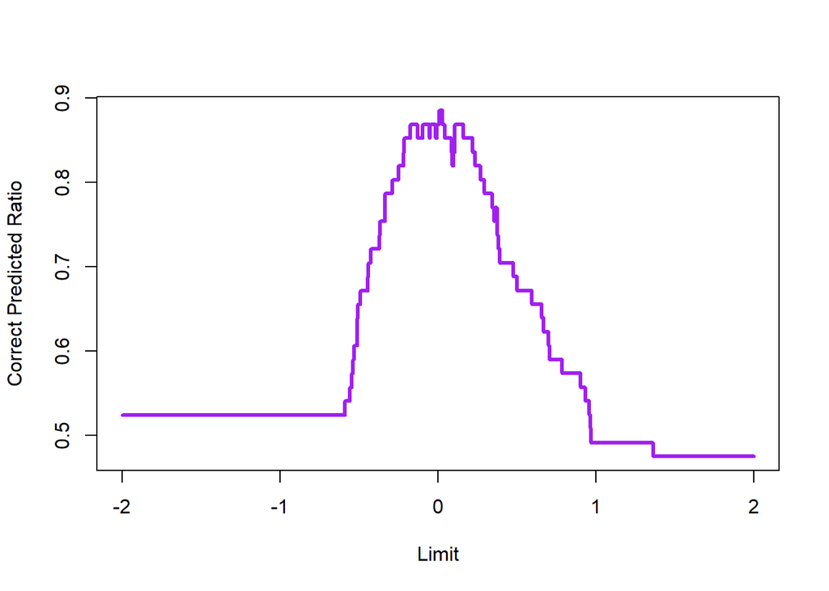

```r
#plotting
plot(acc$limit, acc$ratio, col = "purple", lty = 1, type = "l", xlab =  'Limit', ylab = 'Correct Predicted Ratio',lwd = 3)
```

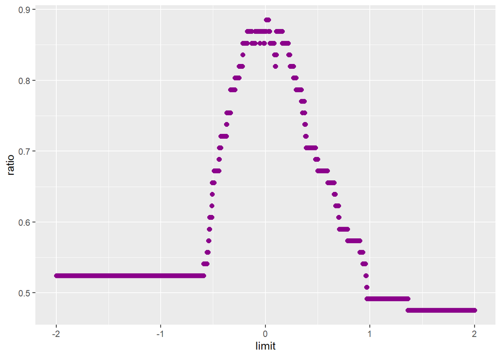

```r
ggplot(data = acc)+geom_point(mapping = aes(x=limit,y=ratio), color = 'magenta4', size = 2)
```

To find the best limit we find maximum correct ratio and find the related limit to it

```r
best = max(acc$ratio)
bestdf = acc[which(acc$ratio == best ),]
head(bestdf,'all')
```

|  | limit | ratio |
| --- | --- | --- |
| 2008 | 0.007 | 0.8852459 |
| 2009 | 0.008 | 0.8852459 |
| 2010 | 0.009 | 0.8852459 |
| 2011 | 0.010 | 0.8852459 |
| 2012 | 0.011 | 0.8852459 |
| 2013 | 0.012 | 0.8852459 |
| 2014 | 0.013 | 0.8852459 |
| 2015 | 0.014 | 0.8852459 |
| 2016 | 0.015 | 0.8852459 |
| 2017 | 0.016 | 0.8852459 |
| 2018 | 0.017 | 0.8852459 |
| 2019 | 0.018 | 0.8852459 |
| 2020 | 0.019 | 0.8852459 |
| 2021 | 0.020 | 0.8852459 |
| 2022 | 0.021 | 0.8852459 |
| 2023 | 0.022 | 0.8852459 |
| 2024 | 0.023 | 0.8852459 |
| 2025 | 0.024 | 0.8852459 |
| 2026 | 0.025 | 0.8852459 |
| 2027 | 0.026 | 0.8852459 |
| 2028 | 0.027 | 0.8852459 |
| 2029 | 0.028 | 0.8852459 |

```r
#choosing maximun one:

print(paste("The best limit is: ", max(bestdf$limit)))
```

```
## [1] "The best limit is:  0.028"
```

# Question 3

## Part A:

The system used to map year works like this:

$yy.00 = yy = spring$

$yy.25 = summer$

$yy.5 = autumn$

$yy.75 = winter$

```r
#reading data:
list<- read.csv(file = 'list.csv')

#removing useless parts
list <- list[-c(1, 2, 3), -1]

#add year to each 4 columns
colnames(list) <- rev(seq(88, 99, 0.25))

#add district
rownames(list) <- 1:22
```

### i) Finding cells containing corrupted values:

Useless cells are filled with one of these: 0,-,’’(empty!),NaN,or any character other than numbers.

Then we fill all the corrupted values with **NaN** to easily find and replace them in the next part.

```r
print("The corrupted values report per column is: ")
```

```
## [1] "The corrupted values report per column is: "
```

```r
#to find out what columns must be removed
uselesscols = c()

for (col in colnames(list)){

    corrupt = which(is.na(list[[col]]) |  list[[col]] == '-' |list[[col]] == '0' | list[[col]] == '' | !grepl('^[0-9]', list[[col]]), arr.ind=TRUE)


    if (length(corrupt) > 0){

      if (as.numeric(col) %% 1 == 0){
        season = "spring"
      }
      else if (as.numeric(col) %%1  == 0.25){
        season = "summer"
      }
      else if (as.numeric(col) %% 1 == 0.5){
        season = "autumn"
      }
      else{
          season = "winter"

      }

      msg = ""

      if (length(corrupt) > 11){
        uselesscols = c(uselesscols, col)
        msg = " More than 50% of data is corrupted "
      }

        print(paste("year ",floor(as.numeric(col))," season ", season," had ", length(corrupt), " corrupted values", msg))
    }


    list[[col]][corrupt] = NA

      #convert to numeric to use later
    list[[col]] = as.numeric(list[[col]])

}
```

```
## [1] "year  98  season  summer  had  2  corrupted values "
## [1] "year  97  season  summer  had  1  corrupted values "
## [1] "year  96  season  summer  had  1  corrupted values "
## [1] "year  96  season  spring  had  2  corrupted values "
## [1] "year  91  season  autumn  had  1  corrupted values "
## [1] "year  90  season  autumn  had  1  corrupted values "
## [1] "year  90  season  summer  had  1  corrupted values "
## [1] "year  90  season  spring  had  4  corrupted values "
## [1] "year  89  season  winter  had  4  corrupted values "
## [1] "year  89  season  autumn  had  6  corrupted values "
## [1] "year  89  season  summer  had  13  corrupted values  More than 50% of data is corrupted "
## [1] "year  89  season  spring  had  9  corrupted values "
## [1] "year  88  season  winter  had  19  corrupted values  More than 50% of data is corrupted "
## [1] "year  88  season  autumn  had  18  corrupted values  More than 50% of data is corrupted "
## [1] "year  88  season  summer  had  19  corrupted values  More than 50% of data is corrupted "
## [1] "year  88  season  spring  had  8  corrupted values "
```

Now we remove columns with more than 50% of corrupted data and also remove the rest of the corrupted values (that are now “NaN”s). Injecting any thing in place of missing values doesn’t seem logical since it’s like producing data. So it is best to remove columns with too many missing values (that actually makes the number of data too little to be useful) and ignore the other missing values in order to avoid causing error.

```r
#remove useless columns:
clean_list <- list[ , -which(names(list) %in% uselesscols)]

##### this part was to replace NaN with median #####

#for (col in colnames(clean_list)) {

    #med = median(clean_list[[col]], na.rm=TRUE)
    #clean_list[[col]][is.na(clean_list[[col]])] <- round(med)}
```

Finally we save the file.

```r
write.csv(clean_list,'clean_list.csv')
```

## Part B:

### i) Traget district : 1

```r
k = 98110232 %% 22
k = k+1

#importing district k+1 data in a separate data
regdf <- data.frame(as.numeric(colnames(clean_list)), as.numeric(t(clean_list[k,])))
colnames(regdf) <- c('Year', 'Cost')

reg = lm(Cost ~ Year, regdf)
summary(reg)
```

```
##
## Call:
## lm(formula = Cost ~ Year, data = regdf)
##
## Residuals:
##     Min      1Q  Median      3Q     Max
## -101944  -63004    1605   34247  256910
##
## Coefficients:
##             Estimate Std. Error t value Pr(>|t|)
## (Intercept) -2851536     389874  -7.314 7.97e-09 ***
## Year           31628       4147   7.627 3.00e-09 ***
## ---
## Signif. codes:  0 '***' 0.001 '**' 0.01 '*' 0.05 '.' 0.1 ' ' 1
##
## Residual standard error: 80000 on 39 degrees of freedom
## Multiple R-squared:  0.5986, Adjusted R-squared:  0.5884
## F-statistic: 58.17 on 1 and 39 DF,  p-value: 2.999e-09
```

The plot:

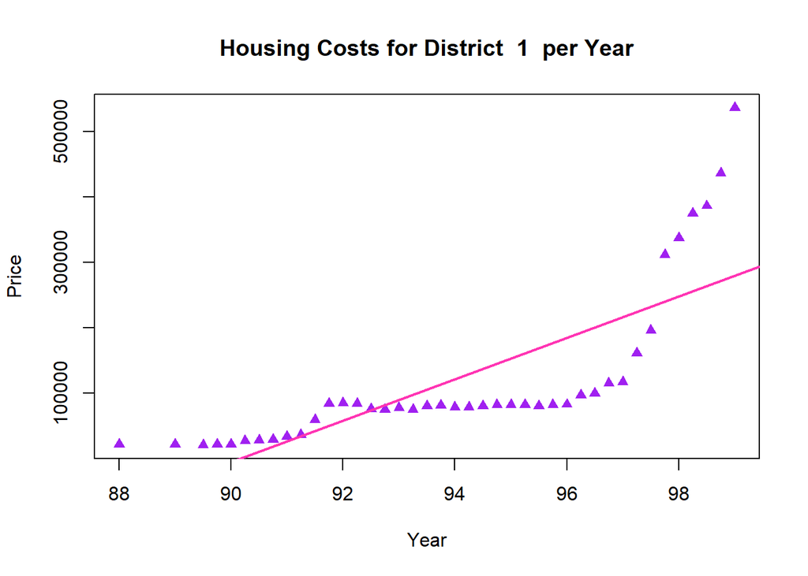

```r
plot(y = regdf$Cost, x = regdf$Year, ylab = 'Price', xlab = 'Year', col = 'purple', main = paste('Housing Costs for District ', k, ' per Year'), pch=17 , lwd = 2)
abline(reg, col = 'maroon1', lwd = 2)
```

```r
options(scipen=5)
```

### ii) Price with respect to district and year

```r
#import data
all = data.frame(district = c(0),year =  c(0),cost = c(0))

# copy:
for (row in rownames(clean_list)) {
    for (col in colnames(clean_list)) {
        all[nrow(all) + 1,] = c(as.numeric(row), as.numeric(col), as.numeric(clean_list[row, col]))
    }
}


# removing the first row which was 0 to initialize the data frame
all <- all[-1,]
head(all)
```

|  | district | year | cost |
| --- | --- | --- | --- |
| 2 | 1 | 99.00 | 536516 |
| 3 | 1 | 98.75 | 436364 |
| 4 | 1 | 98.50 | 386496 |
| 5 | 1 | 98.25 | 374741 |
| 6 | 1 | 98.00 | 337304 |
| 7 | 1 | 97.75 | 311466 |

```r
tail(all)
```

|  | district | year | cost |
| --- | --- | --- | --- |
| 898 | 22 | 90.25 | 15071 |
| 899 | 22 | 90.00 | 12802 |
| 900 | 22 | 89.75 | 12283 |
| 901 | 22 | 89.50 | 11019 |
| 902 | 22 | 89.00 | 9909 |
| 903 | 22 | 88.00 | NA |

Now we find the regression:

```r
reg = lm(cost ~ year + district, all)

summary(reg)
```

```
##
## Call:
## lm(formula = cost ~ year + district, data = all)
##
## Residuals:
##    Min     1Q Median     3Q    Max
## -73136 -28396  -9460  16211 386550
##
## Coefficients:
##               Estimate Std. Error t value Pr(>|t|)
## (Intercept) -1176390.9    55704.0  -21.12   <2e-16 ***
## year           13665.0      591.5   23.10   <2e-16 ***
## district       -4584.5      271.3  -16.90   <2e-16 ***
## ---
## Signif. codes:  0 '***' 0.001 '**' 0.01 '*' 0.05 '.' 0.1 ' ' 1
##
## Residual standard error: 50550 on 859 degrees of freedom
##   (40 observations deleted due to missingness)
## Multiple R-squared:  0.4814, Adjusted R-squared:  0.4801
## F-statistic: 398.6 on 2 and 859 DF,  p-value: < 2.2e-16
```

### iii) Finding price as a function of a single district and year (dummy variable)

Here each district is treated as a single independent variable. To do so our data frame must have 23 columns, meaning there is one column for each district except for district 1.Later if all the district columns are 0, we’ll know it’s because data belongs to district 1.

```r
#import data
all = data.frame(dist2 = c(0),dist3 = c(0),dist4 = c(0), dist5 = c(0),dist6 = c(0),dist7 =c(0),
                 dist8 = c(0),dist9 = c(0),dist10 = c(0),
                 dist11= c(0),dist12 = c(0),dist13 = c(0),dist14 = c(0),dist15 = c(0)
                 ,dist16 = c(0),dist17 = c(0),dist18 = c(0),dist19= c(0),dist20 = c(0),dist21 = c(0),dist22 = c(0),year =  c(0),cost = c(0))


which_dist <- function(dist) {
    vec = c(rep(0,21))
    vec[dist-1] <- 1
    return (vec)
}

# copy:
for (row in rownames(clean_list)) {
    for (col in colnames(clean_list)) {

      #if the data is for district 1 then add 0 to all district columns
        if (as.numeric(row) == 1){
          all[nrow(all) + 1,] = c(c(rep(0,21)), as.numeric(col), as.numeric(clean_list[row, col]))
        }

      else{
        all[nrow(all) + 1,] = c(which_dist(as.numeric(row)), as.numeric(col), as.numeric(clean_list[row, col]))
      }
    }
}



# removing the first row which was 0 to initialize the data frame
all <- all[-1,]
head(all)
```

|  | dist2 | dist3 | dist4 | dist5 | dist6 | dist7 | dist8 | dist9 | dist10 | dist11 | dist12 | dist13 | dist14 | dist15 | dist16 | dist17 | dist18 | dist19 | dist20 | dist21 | dist22 | year | cost |
| --- | --- | --- | --- | --- | --- | --- | --- | --- | --- | --- | --- | --- | --- | --- | --- | --- | --- | --- | --- | --- | --- | --- | --- |
| 2 | 0 | 0 | 0 | 0 | 0 | 0 | 0 | 0 | 0 | 0 | 0 | 0 | 0 | 0 | 0 | 0 | 0 | 0 | 0 | 0 | 0 | 99.00 | 536516 |
| 3 | 0 | 0 | 0 | 0 | 0 | 0 | 0 | 0 | 0 | 0 | 0 | 0 | 0 | 0 | 0 | 0 | 0 | 0 | 0 | 0 | 0 | 98.75 | 436364 |
| 4 | 0 | 0 | 0 | 0 | 0 | 0 | 0 | 0 | 0 | 0 | 0 | 0 | 0 | 0 | 0 | 0 | 0 | 0 | 0 | 0 | 0 | 98.50 | 386496 |
| 5 | 0 | 0 | 0 | 0 | 0 | 0 | 0 | 0 | 0 | 0 | 0 | 0 | 0 | 0 | 0 | 0 | 0 | 0 | 0 | 0 | 0 | 98.25 | 374741 |
| 6 | 0 | 0 | 0 | 0 | 0 | 0 | 0 | 0 | 0 | 0 | 0 | 0 | 0 | 0 | 0 | 0 | 0 | 0 | 0 | 0 | 0 | 98.00 | 337304 |
| 7 | 0 | 0 | 0 | 0 | 0 | 0 | 0 | 0 | 0 | 0 | 0 | 0 | 0 | 0 | 0 | 0 | 0 | 0 | 0 | 0 | 0 | 97.75 | 311466 |

```r
tail(all)
```

|  | dist2 | dist3 | dist4 | dist5 | dist6 | dist7 | dist8 | dist9 | dist10 | dist11 | dist12 | dist13 | dist14 | dist15 | dist16 | dist17 | dist18 | dist19 | dist20 | dist21 | dist22 | year | cost |
| --- | --- | --- | --- | --- | --- | --- | --- | --- | --- | --- | --- | --- | --- | --- | --- | --- | --- | --- | --- | --- | --- | --- | --- |
| 898 | 0 | 0 | 0 | 0 | 0 | 0 | 0 | 0 | 0 | 0 | 0 | 0 | 0 | 0 | 0 | 0 | 0 | 0 | 0 | 0 | 1 | 90.25 | 15071 |
| 899 | 0 | 0 | 0 | 0 | 0 | 0 | 0 | 0 | 0 | 0 | 0 | 0 | 0 | 0 | 0 | 0 | 0 | 0 | 0 | 0 | 1 | 90.00 | 12802 |
| 900 | 0 | 0 | 0 | 0 | 0 | 0 | 0 | 0 | 0 | 0 | 0 | 0 | 0 | 0 | 0 | 0 | 0 | 0 | 0 | 0 | 1 | 89.75 | 12283 |
| 901 | 0 | 0 | 0 | 0 | 0 | 0 | 0 | 0 | 0 | 0 | 0 | 0 | 0 | 0 | 0 | 0 | 0 | 0 | 0 | 0 | 1 | 89.50 | 11019 |
| 902 | 0 | 0 | 0 | 0 | 0 | 0 | 0 | 0 | 0 | 0 | 0 | 0 | 0 | 0 | 0 | 0 | 0 | 0 | 0 | 0 | 1 | 89.00 | 9909 |
| 903 | 0 | 0 | 0 | 0 | 0 | 0 | 0 | 0 | 0 | 0 | 0 | 0 | 0 | 0 | 0 | 0 | 0 | 0 | 0 | 0 | 1 | 88.00 | NA |

```r
reg = lm(cost~. , all)

summary(reg)
```

```
##
## Call:
## lm(formula = cost ~ ., data = all)
##
## Residuals:
##    Min     1Q Median     3Q    Max
## -65715 -31007  -7331  18936 351891
##
## Coefficients:
##               Estimate Std. Error t value Pr(>|t|)
## (Intercept) -1174875.2    53116.2 -22.119  < 2e-16 ***
## dist2          -7230.6    10540.5  -0.686 0.492915
## dist3           7501.5    10540.5   0.712 0.476863
## dist4         -40248.7    10540.5  -3.818 0.000144 ***
## dist5         -51817.7    10606.5  -4.885 1.24e-06 ***
## dist6         -16646.3    10675.7  -1.559 0.119308
## dist7         -45672.7    10540.5  -4.333 1.65e-05 ***
## dist8         -56417.7    10606.5  -5.319 1.34e-07 ***
## dist9         -88050.3    10988.0  -8.013 3.73e-15 ***
## dist10        -82679.0    10606.5  -7.795 1.90e-14 ***
## dist11        -82367.8    10540.5  -7.814 1.65e-14 ***
## dist12        -87249.3    10540.5  -8.277 4.93e-16 ***
## dist13        -65572.4    10606.4  -6.182 9.85e-10 ***
## dist14        -74169.7    10606.3  -6.993 5.50e-12 ***
## dist15        -91442.6    10606.3  -8.622  < 2e-16 ***
## dist16        -91895.1    10825.0  -8.489  < 2e-16 ***
## dist17       -103133.4    10991.5  -9.383  < 2e-16 ***
## dist18       -101581.7    10749.0  -9.450  < 2e-16 ***
## dist19        -98511.5    10984.5  -8.968  < 2e-16 ***
## dist20       -102988.3    10606.4  -9.710  < 2e-16 ***
## dist21        -89699.7    10901.3  -8.228 7.21e-16 ***
## dist22        -76320.6    10606.5  -7.196 1.38e-12 ***
## year           13785.1      559.7  24.631  < 2e-16 ***
## ---
## Signif. codes:  0 '***' 0.001 '**' 0.01 '*' 0.05 '.' 0.1 ' ' 1
##
## Residual standard error: 47720 on 839 degrees of freedom
##   (40 observations deleted due to missingness)
## Multiple R-squared:  0.5485, Adjusted R-squared:  0.5366
## F-statistic: 46.32 on 22 and 839 DF,  p-value: < 2.2e-16
```

### iv) Which one is better? ii or iii?

District here, is most certainly playing a role but not as a number. In part **ii** we used the number of the district as a real number! meaning for district 22 for example, we set $x = 22$ and for district 3, $x = 3$. Treating this feature (which is a non-numeric factor rather than a real number) this way causes error in calculations. Nevertheless when a data belongs to district $x$ for example, **we know** that for sure, this data cannot belong to any other district, hence, estimating price as a function of *all* districts for a single data is wrong. The order of district numbers may not be fit to order of prices in those. For example assume that typically district 1 is more expensive than district 3 and district 3 is more expensive than district 2, however $ 3 > 2 > 1$ but we had $Price(1) > Price(3) > Price(2) $. This disorderliness effects the linearity and reduces the R-squared value.

This is an intuition on why the estimation in part **iii** is better. Now let’s take a look at numbers.

**ii) Residual standard error: 50550 on 859 degrees of freedom**

```
Adjusted R-squared:  0.4801
```

3. Residual standard error: 47720 on 839 degrees of freedom

Adjusted R-squared: 0.5366

We know the larger the R-squared the better is the model. Also the reduction of Residual standard error shows that the second regression is working better.

## Part C

### i)

```r
k = 98110232 %% 33

print(paste("k =",k))
```

```
## [1] "k = 11"
```

let’s see what are seasons $k$ and $k+1$ (11 and 12)

```r
sea11 = t <- 90.75 + k / 4
sea12 = sea11 + 0.25
print(paste("season" , k ,"is", sea11 , "and season", k+1 ,"is", sea12))
```

```
## [1] "season 11 is 93.5 and season 12 is 93.75"
```

Thus we will be analyzing data of fall and winter of year 93.

Let’s calculate mean and variance for each season’s price:

```r
y_i = clean_list[[as.character(sea12)]]

x_i = clean_list[[as.character(sea11)]]

print(paste("mean of x_i is", round(mean(x_i),2), "and mean of y_i is",  round(mean(y_i),2)))
```

```
## [1] "mean of x_i is 40224.32 and mean of y_i is 40134.91"
```

```r
print(paste("variance of x_i is" , round(var(x_i),2),"and variance of y_i is" , round(var(y_i),2)))
```

```
## [1] "variance of x_i is 498544150.99 and variance of y_i is 522272774.09"
```

```r
print(paste("The difference between average price in those seasons is mean(x_i)-mean(y_i) =", round(mean(x_i)-mean(y_i),2)))
```

```
## [1] "The difference between average price in those seasons is mean(x_i)-mean(y_i) = 89.41"
```

and now we compute p-value:
$$t=\frac{m_{A}-m_{B}}{\sqrt{\frac{S^{2}}{n_{A}}+\frac{S^{2}}{n_{B}}}}$$
where, - $m_{A}$ and $m_{B}$ represent the mean value of the group $A$ and $B$, respectively.

- $n_{A}$ and $n_{B}$ represent the sizes of the group $\mathrm{A}$ and $\mathrm{B}$, respectively.
- $S^{2}$ is an estimator of the pooled variance of the two groups. It can be calculated as follow:

$$S^{2}=\frac{\sum\left(x-m_{A}\right)^{2}+\sum\left(x-m_{B}\right)^{2}}{n_{A}+n_{B}-2}$$

with degrees of freedom (df): $d f=n_{A}+n_{B}-2$.

```r
n = length(x_i)
m = length(y_i)
d = (n - 1) * (var(x_i)) + ((m-1)*var(y_i))
Sp = d*(1/(m+n-2))

denum = sqrt(Sp*2/n)
t_value = (mean(x_i) - mean(y_i)) / denum

#test = t.test(x_i,y_i)
#test$p.value


p_value = pt(q = t_value, df = n+ m - 2)

print(paste("p_value =", round(p_value,5)))
```

```
## [1] "p_value = 0.50521"
```

Assuming a threshold of $0.05$ for $P_{value}$ we fail to reject to null hypothesis since $P_{value} > 0.05$

Thus with significance level of $5%$ we **can’t say that prices have changed** in this time.

### ii) Repeat everything on $z_i$

$$z_i = x_i - y_i$$

$$\bar{z_i} = \bar{x_i}-\bar{y_i}$$

```r
z_i = x_i - y_i

denum = sqrt(var(z_i) / length(z_i))

p_value = pt(q = mean(z_i) / denum , df = length(z_i) - 1, lower.tail = T)

print(paste("mean(z_i) = ", round(mean(z_i), 2),"var(z_i) = ", round(var(z_i), 2) ))
```

```
## [1] "mean(z_i) =  89.41 var(z_i) =  493758.54"
```

```r
print(paste("P_value =", round(p_value,5)))
```

```
## [1] "P_value = 0.72149"
```

still with a threshold of $0.05$ for $P_{value}$ we fail to reject to null hypothesis since $P_{value} > 0.05$

Thus with significance level of $5%$ we **can’t say that prices have changed** in this time. Actually $P_{value}$ has increased!

### iii) which is better? ii or i?

Looking at the variance in both parts, we have much less variance in part ii, however in part i, $x_i$ and $y_i$ have large variances each. Thus we have a narrower curve in part ii, which results in more accurate results. Here the increase in P-value in part ii shows that, in part ii the fact that null hypothesis can’t be rejected becomes more certain. When we pair data before analyzing, we don’t merge the data of districts and that reduces error.